# Assignment4

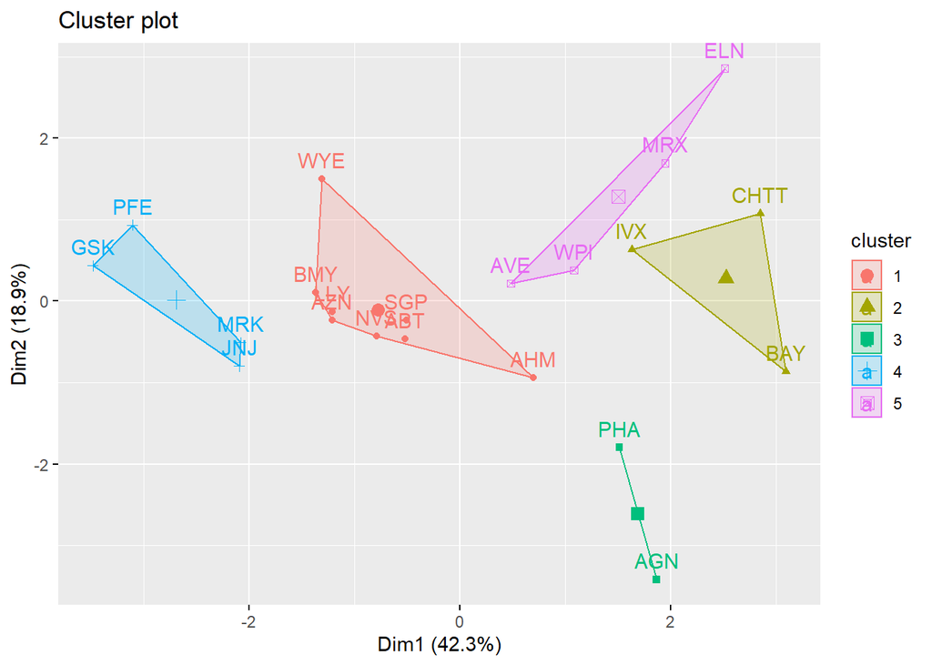

```r
fviz_cluster(final, data = dataframe)
```

```r
P%>%
  mutate(Cluster = final$cluster) %>%
  group_by(Cluster)%>% summarise_all("mean")
```

| Cluster | Market_Cap | Beta | PE_Ratio | ROE | ROA | Asset_Turnover | Leverage | Rev_Growth | Net_Profit_Margin |
| --- | --- | --- | --- | --- | --- | --- | --- | --- | --- |
| 1 | 55.810000 | 0.41375 | 20.2875 | 28.73750 | 12.687500 | 0.7375 | 0.371250 | 5.591250 | 19.350000 |
| 2 | 6.636667 | 0.87000 | 24.6000 | 16.46667 | 4.166667 | 0.6000 | 1.653333 | 5.733333 | 7.033333 |
| 3 | 31.910000 | 0.40500 | 69.5000 | 13.20000 | 5.600000 | 0.7500 | 0.475000 | 12.080000 | 6.400000 |
| 4 | 157.017500 | 0.48000 | 22.2250 | 44.42500 | 17.700000 | 0.9500 | 0.220000 | 18.532500 | 19.575000 |
| 5 | 13.100000 | 0.59750 | 17.6750 | 14.57500 | 6.200000 | 0.4250 | 0.635000 | 30.142500 | 15.650000 |

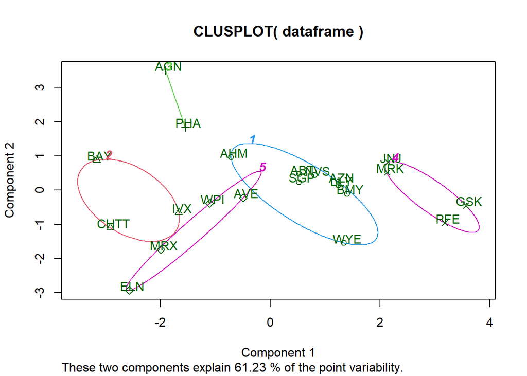

```r
clusplot(dataframe,final$cluster, color = TRUE, labels = 2,lines = 0)
```

b. interpreting clusters with respect to numerical variable used in clustering Cluster1 - AHM,SGP,WYE,BMY,AZN, ABT, NVS, LLY Cluster2 - BAY, CHTT, IVX Cluster3 - AGN, PHA Cluster4 - JNJ, MRK, PFE,GSK Cluster5 - WPI, MRX,ELN,AVE

```r
ClusterFormed<- Pharmadataset[,c(12,13,14)]%>% mutate(clusters = final$cluster)%>% arrange(clusters, ascending = TRUE)
ClusterFormed
```

|  | Median_Recommendation | Location | Exchange | clusters |
| --- | --- | --- | --- | --- |
| ABT | Moderate Buy | US | NYSE | 1 |
| AHM | Strong Buy | UK | NYSE | 1 |
| AZN | Moderate Sell | UK | NYSE | 1 |
| BMY | Moderate Sell | US | NYSE | 1 |
| LLY | Hold | US | NYSE | 1 |
| NVS | Hold | SWITZERLAND | NYSE | 1 |
| SGP | Hold | US | NYSE | 1 |
| WYE | Hold | US | NYSE | 1 |
| BAY | Hold | GERMANY | NYSE | 2 |
| CHTT | Moderate Buy | US | NASDAQ | 2 |

[output cut: 11 more lines]

3. is there a pattern in the cluster with respect to numerical variable (10 to 12)?

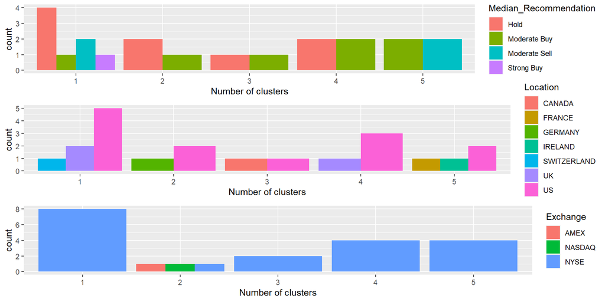

```r
p1<-ggplot(ClusterFormed, mapping = aes(factor(clusters), fill=Median_Recommendation))+geom_bar(position = 'dodge')+labs(x ='Number of clusters')
p2<- ggplot(ClusterFormed, mapping = aes(factor(clusters),fill = Location))+geom_bar(position = 'dodge')+labs(x ='Number of clusters')
p3<- ggplot(ClusterFormed, mapping = aes(factor(clusters),fill = Exchange))+geom_bar(position = 'dodge')+labs(x ='Number of clusters')
grid.arrange(p1,p2,p3)
```

As per graph shown above, Cluster1 Suggests to Hold to Moderate Sell Cluster2 Suggests to Hold Cluster3 Suggests to Hold to Moderate Buy Cluster4 suggests to Hold to Moderate Buy Cluster5 suggests to Moderate Buy to Moderate Sell

4. giving names to each cluster: Cluster1- Sell Cluster, Cluster2- Hold Cluster, Cluster3- Buy Cluster, Cluster4- High Buy Cluster, Cluster5- Buy Sell Cluster,